# Getting Started: Simulation and Resampling Methods

Statistical Computing for Data Analysis

# Outline

- Probability in R
- Pseudo random number generation
- Random sampling

# Probability in Statistics

**Intuition:** How likely is an event to happen?

**Formalize this:** We study a random variable $X$ that represents the outcome of a random phenomenon

**Example:** $X$ = corn yield

We want to

1. be able to understand the distribution of our random variable
2. simulation random draws from this distribution.

# Common Distributions

You’ll use these often for simulation:

- Normal
- Binomial
- Chi-square
- Exponential
- Gamma
- Poisson
- Uniform
- $t$ distribution

# The Prefix System: d, p, q, r

R uses a consistent naming convention for probability distributions. You append the prefix to the core name of the distribution (e.g., `norm`, `t`, `pois`, `binom`).

- `d`: Density function (or probability mass functionfor discrete distributions)
- `p`: Probability (Cumulative Distribution Function)
- `q`: Quantile (Inverse CDF)
- `r`: Random generation

Each function requires the specific parameters that define that distribution’s shape.

# Brief Stats Review: Density Functions

**Probability Density Function (PDF): $f(x)$**

- Describes the relative likelihood of a continuous random variable taking on a specific value.
- The height of the curve is *not* a probability. Probability is the area under the curve: $P(a \le X \le b) = \int_{a}^{b} f(x) dx$.
- **In R:** `dnorm(x, mean = 0, sd = 1)` evaluates the density $f(x)$ at $x$.

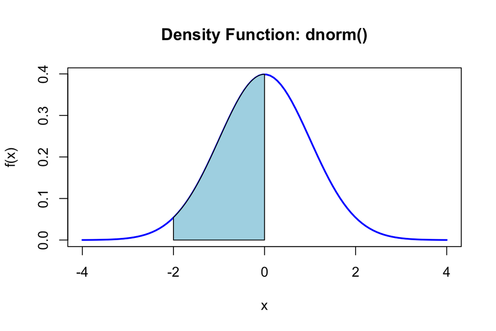

```r
# Plotting the Standard Normal Density
x <- seq(-4, 4, length.out = 100)
plot(x, dnorm(x), type = "l", lwd = 2, col = "blue",
     main = "Density Function: dnorm()", ylab = "f(x)")
polygon(c(-2, seq(-2, 0, 0.01), 0), c(0, dnorm(seq(-2, 0, 0.01)), 0), col = "lightblue")
```

What is the pdf $f(x)$ evaluated at a specific value?

```r
dnorm(2,0,1) ## f(x=2) assuming X ~ N(0,1)
```

```
## [1] 0.05399097
```

# Brief Stats Review: Distribution Functions

**Cumulative Distribution Function (CDF): $F(x)$**

- Returns the probability that a random variable $X$ is less than or equal to a specific value $x$
- **Mathematical Definition:** $F(x) = P (X \le x) = \int_{-\infty}^{x} f(t) dt$.
- **In R:** `pnorm(q, mean = 0, sd = 1)` calculates this left-tail probability for a given value $q$.

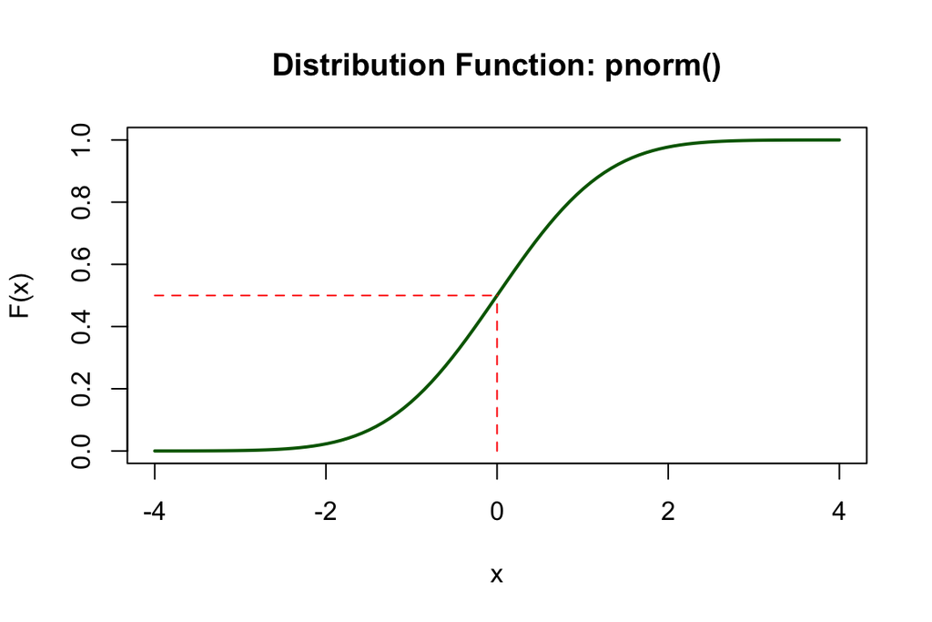

```r
# Plotting the Standard Normal CDF
plot(x, pnorm(x), type = "l", lwd = 2, col = "darkgreen",
     main = "Distribution Function: pnorm()", ylab = "F(x)")
segments(x0 = 0, y0 = 0, x1 = 0, y1 = pnorm(0), lty = 2, col = "red")
segments(x0 = -4, y0 = pnorm(0), x1 = 0, y1 = pnorm(0), lty = 2, col = "red")
```

What is the CDF $F(x)$ evaluated at a specific value?

```r
pnorm(2,0,1) ## P(X <= 2) = F(2) assuming X ~ N(0,1)
```

```
## [1] 0.9772499
```

# Brief Stats Review: Quantiles

**Quantile Function: $F^{-1}(p)$**

- - **Intuition:** Instead of asking “What is the probability of observing a value less than $x$?”, we ask, “What is the value $x$ that traps a specific probability $p$ below it?”
- Think of standardized test percentiles: If you are in the 90th percentile, $p = 0.90$. The quantile function tells you the exact test score $x$ that corresponds to that rank.
- Formally it is the inverse of the CDF: $F^{-1}(p)$. This says given a probability $p$ (where $0 \le p \le 1$), it returns the value $x$ such that $P(X \le x) = p$.
- **In R:** `qnorm(p, mean = 0, sd = 1)` finds the value corresponding to the $p$-th probability.

```r
# Finding the 95th quantile
p <- 0.95
q_val <- qnorm(p)
q_val
```

```
## [1] 1.644854
```

```r
# Verifying the inverse relationship: the area to the left is 0.95
pnorm(q_val)
```

```
## [1] 0.95
```

# Generating Random Data

Random Number GenerationTo simulate data from a theoretical distribution, we use the `r` prefix.

**In R:** `rnorm(n, mean = 0, sd = 1)` generates a vector of length $n$ containing pseudo-random draws from the specified *normal distribution*.

```r
# Simulate 5 standard normal random variables
rnorm(5)
```

```
## [1]  0.2057122  1.4940780 -1.7490528 -1.1078900  1.5682049
```

# Reproducibility: set.seed()

Why use set.seed()?

- Computers use deterministic algorithms (pseudo-randomness).
- Setting a seed initializes the starting point of the algorithm. This guarantees that your code will produce the exact same sequence of “random” numbers every time it is run.
- Without a seed: results are still fine statistically, but you can’t match someone else’s output.

```r
set.seed(4279)
rnorm(3)
```

```
## [1]  1.602368  1.161447 -2.093846
```

```r
set.seed(4279) # Resetting the seed to the exact same starting point
rnorm(3)       # Yields the exact same draws
```

```
## [1]  1.602368  1.161447 -2.093846
```

# Example: Student’s t-Distribution

**Continuous, symmetric, but with heavier tails than the normal distribution.**

- Core name: `t`
- Parameter: `df` (degrees of freedom)

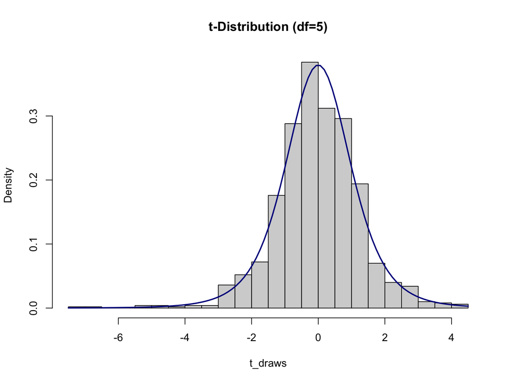

```r
# Generate 1000 random draws from a t-distribution with 5 df
t_draws <- rt(n = 1000, df = 5)

# Compare the density of our sample to the theoretical density
hist(t_draws, probability = TRUE, breaks = 30, col = "lightgray", main = "t-Distribution (df=5)")
curve(dt(x, df = 5), add = TRUE, col = "darkblue", lwd = 2)
```

# Example: Poisson Distribution

**Discrete distribution modeling the number of events occurring in a fixed interval.**

- Core name: `pois`
- Parameter: `lambda` ($\lambda$, the expected rate of occurrence)
- Note: Because it is discrete, `dpois()` calculates the exact Probability Mass Function (PMF), $P(X = x)$.

```r
# Probability of observing exactly 3 events when the average rate is 2
dpois(x = 3, lambda = 2)
```

```
## [1] 0.180447
```

```r
# Generate 10 random counts with rate lambda = 2
rpois(n = 10, lambda = 2)
```

```
##  [1] 1 1 2 2 4 2 0 4 1 2
```

# Example: Binomial Distribution

**Discrete distribution modeling the number of successes in $n$ independent trials..**

- Core name: `binom`
- Parameters: `size` (number of trials, $n$) and `prob` (probability of success on each trial, $p$

```r
# Probability of getting exactly 7 heads in 10 coin flips (fair coin)
dbinom(x = 7, size = 10, prob = 0.5)
```

```
## [1] 0.1171875
```

```r
# Simulate 5 different experiments of 10 coin flips each
rbinom(n = 5, size = 10, prob = 0.5)
```

```
## [1] 6 6 5 5 6
```

# From Theoretical to Empirical Distributions

**The Empirical Cumulative Distribution Function (ECDF): $\hat{F}_n(x)$**

- Previously, we used functions like `pnorm()` to evaluate the *theoretical* CDF, $F(x)$, of a known probability distribution.
- In practice, we rarely know the true distribution. Instead, we have a sample of observed data: $x_1, x_2, \dots, x_n$.
- We estimate the theoretical CDF using the **Empirical CDF**, which is a step function that jumps by $1/n$ at each observed data point.
- **Mathematical Definition:**
  $$\hat{F}_n(x) = \frac{1}{n} \sum_{i=1}^n I(x_i \le
  x)$$
  where $I(\cdot)$ is the indicator function.

# Computing and Plotting the ECDF in R

The `ecdf()` function takes a numeric vector of data and returns a *function* that evaluates the step distribution. We can visualize how well our empirical data matches the theoretical distribution we drew it from.

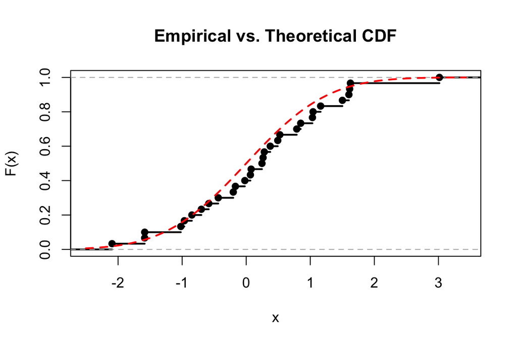

```r
set.seed(4279)
# 1. Generate a small sample from a standard normal distribution
obs_data <- rnorm(30)

# 2. Compute the ECDF
my_ecdf <- ecdf(obs_data)

# 3. Plot the empirical step function
plot(my_ecdf, main = "Empirical vs. Theoretical CDF", xlab = "x", ylab = "F(x)", lwd = 2)

# 4. Overlay the theoretical true CDF (pnorm) for comparison
curve(pnorm(x), add = TRUE, col = "red", lwd = 2, lty = 2)
```

# Random Sampling from Finite Sets: sample()

**Moving beyond theoretical probability distributions**

- The r-prefix functions (`rnorm`, `rpois`) generate data by sampling from theoretical probability models.
- When we want to sample directly from an existing, finite vector of data (like our obs_data vector, or a specific set of categories), we use base R’s sample() function.

**Syntax:** `sample(x, size, replace = FALSE, prob = NULL)`

- `x`: A vector of elements to choose from.
- `size`: The number of items to choose.
- `replace`: Should sampling be with or without replacement?

# Sampling Without Replacement

**Default Behavior** (`replace = FALSE`)

- Once an element is drawn from the vector, it is removed from the candidate pool and cannot be selected again.
- Statistical Application: This simulates Simple Random Sampling (SRS) without replacement from a finite population, or drawing cards from a deck.
- The size argument cannot exceed the length of the vector `x`.

```r
set.seed(4279)
# Draw 5 unique students from a roster of 100
sample(x = 1:100, size = 5, replace = FALSE)
```

```
## [1] 10 49 21 85 37
```

```r
# Permutation: If size equals the length of x, it shuffles the vector
sample(x = c("A", "B", "C"), size = 3, replace = FALSE)
```

```
## [1] "C" "A" "B"
```

# Sampling With Replacement

**Resampling** (`replace = TRUE`)

- Once an element is drawn, it is “returned” to the pool and can be selected multiple times.
- **Statistical Application:** This is the fundamental mechanism behind resampling methods, such as the **Bootstrap**. When we sample with replacement from our own observed data, we are treating the Empirical CDF, $\hat{F}_n(x)$, as the true data-generating distribution.
- The `size` argument can be arbitrarily large.

```r
set.seed(4279)
# Simulating 10 rolls of a fair 6-sided die
sample(x = 1:6, size = 10, replace = TRUE)
```

```
##  [1] 2 1 5 5 5 4 4 5 5 5
```

```r
# Bootstrap sample: Sampling from our previously generated obs_data
bootstrap_sample <- sample(x = obs_data, size = length(obs_data), replace = TRUE)
head(bootstrap_sample)
```

```
## [1]  0.4923485  1.0335527 -0.4363482  1.6023681  0.2630763  3.0152879
```